# indelsClassification: classification of short insertions and deletions for mutational signature analysis

Ferran Nadeu

10/27/2019

This functions takes as input a 4-column matrix with CHROMOSOME, POSITION, REF, ALT and returns a list with two objects:

- Matrix with the 5’ and 3’ context of the indels and their classification (note that the nucleotide at POSITION is included both in the 5’ and 3’ context sequences)
- Graphical representation of the classification

# indelsClassification - Toy example

## Libraries

```r
library(GenomicRanges)
library(BSgenome)
library(BSgenome.Hsapiens.UCSC.hg19)
library(Rsamtools)
library(knitr) # just for fance rmarkdown table
```

## Source indelsClassification function

```r
source("indelsClassification.R")
```

## Load data

```r
INDELS <- read.table("indelsClassification_toyExample.tsv", sep = "\t", header = T, stringsAsFactors = F)
# head(INDELS)
kable(head(INDELS), align = "l")
```

| Chrom | Pos | Ref | Alt |
| --- | --- | --- | --- |
| 1 | 20496058 | TAAAG | T |
| 1 | 23665181 | GT | G |
| 1 | 30315110 | GA | G |
| 1 | 50723455 | T | TA |
| 1 | 62416864 | GA | G |
| 1 | 63669074 | CT | C |

## Run indelsClassification function

```r
pdf(NULL)
out <- indelsClassification(mat = INDELS)
while (!is.null(dev.list()))  dev.off()
```

## Check the classification matrix

```r
# head(out[[1]])
kable(head(out[[1]]), align = "l")
```

| CHR | POSITION | REF | ALT | context5p | context3p | indelClass | indelSubClass | indelRepeats |
| --- | --- | --- | --- | --- | --- | --- | --- | --- |
| chr1 | 20496058 | TAAAG | T | GTAAT | TAAAGAAAATCCCAGTGCCGTAAGCAAAGAG | deletion with microhomology | 4 | 3 |
| chr1 | 23665181 | GT | G | TG | GTTACATTCAATA | 1bp deletion | T:A | 2 |
| chr1 | 30315110 | GA | G | GG | GAAAAAAAGGCAA | 1bp deletion | T:A | 6+ |
| chr1 | 50723455 | T | TA | GT | TAAAAAAACAGTG | 1bp insertion | T:A | 5+ |
| chr1 | 62416864 | GA | G | GG | GAAAAAAAAAGTT | 1bp deletion | T:A | 6+ |
| chr1 | 63669074 | CT | C | TC | CTTTTTTTTTGGT | 1bp deletion | T:A | 6+ |

## Plot indel classification

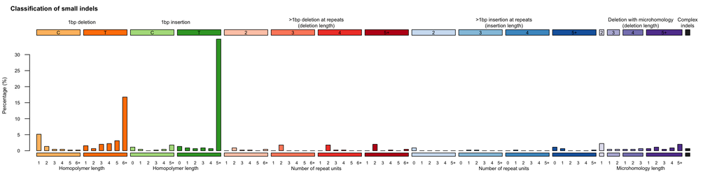

```r
out[[2]]
```

```r
# grid::grid.newpage() # run this in your R script to open a new page for the next plot
```

# Re-use previous annotation

It is useful for large datasets so you only need to annotate the indels once, and then you can re-use this annotation when plotting again the same indels or just a subset of them.

```r
INDELS <- cbind(INDELS, out[[1]][, 5:9])
pdf(NULL)
out <- indelsClassification(mat = INDELS[1:200, ], classColumn = "indelClass", subClassColumn = "indelSubClass", repeatsColumns = "indelRepeats")
while (!is.null(dev.list()))  dev.off()
```

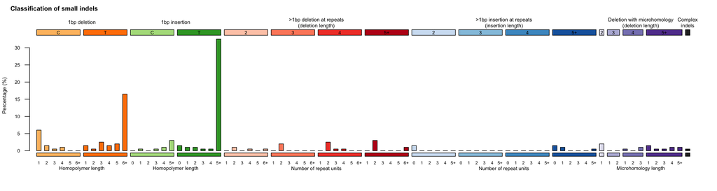

```r
out[[2]]
```

```r
# grid::grid.newpage() # run this in your R script to open a new page for the next plot
```

# Customize plot

You can easily change the title of your plot, add a subtitle with the number of indels annotated, and change the scale of the y axis.

```r
pdf(NULL)
out <- indelsClassification(mat = INDELS, classColumn = "indelClass", subClassColumn = "indelSubClass", repeatsColumns = "indelRepeats", title = "My title", subtitle = T, yScale = "count")
while (!is.null(dev.list()))  dev.off()
```

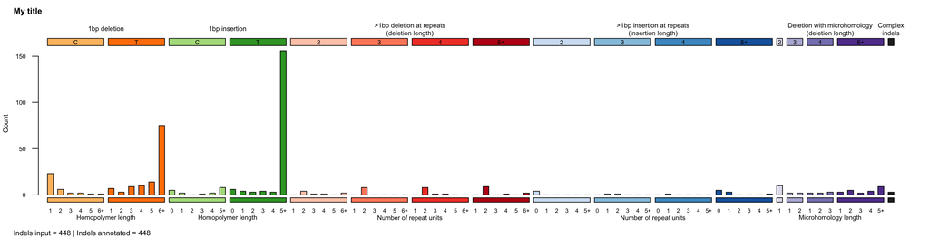

```r
out[[2]]
```